# R Notebook

Kiante Fernandez

# Main Hypotheses

1. Consistent with previous research on behavioral economics and moral decision making, we hypothesize that participants will be more psychologically risk averse to harm than gain motivated.
2. Participants risk aversion to harm will change as the cognitive domain being treated changes. Specifically, participants will be more risk averse to mood, and self-control because these are more central to self-identity.
3. Participants who are more affluent, educated, liberal, and younger will be risk seeking relative to the average risky decision making behavior observed when judging treatments for others.
- note: we need income, age, education, and political affli here.
4. In a classification model, the proportion of benefit to harm ratio will be more predictive of whether someone chooses an experimental treatment than the benefits or risks alone.

## Set the stage

```r
#this will load the libraries and WILL INSTALL IF YOU DO NOT HAVE THE PACKAGE (heads up)
packages <- c('readr','dplyr','tidyselect','magrittr','ggplot2','ggpubr','reshape2', 'stringr', 'psych')
if (length(setdiff(packages, rownames(installed.packages()))) > 0) {
  install.packages(setdiff(packages, rownames(installed.packages())))
}
lapply(packages, library, character.only = TRUE)
```

[output not shown]

```r
rm(list=ls())
```

```r
#this removes the subjects task data that we collected on an accidently deployment
REMOVE = c(
  "wpchz8fz",
  "tdDTyNLl",
  "CUyB01Th",
  "d9UbV0sj",
  "PiGCo5DO",
  "yCZDIVJF",
  "WUTFOue2",
  "Rp8H93tM",
  "9Z5vJ7oT",
  "esSkjqdS",
  "XNHqndg3",
  "spGR9XvT",
  "qf27dbHj",
  "y6m1AOsD",
  "hgbHHiLn",
  "Ly8mJkxP"
)
for (i in REMOVE){
cleanPilot <- cleanPilot %>%
  filter(!str_detect(user_id, i))
}
```

### Add Survey Data

```r
survey = read.csv("../data/Qualtrics Data/May_20_2020.csv", header=TRUE, comment.char="#", stringsAsFactors=TRUE)
survey <- filter(survey, batch >= 3)
survey$batch <- as.factor(survey$batch) #616 raw pilot data
```

```r
#Remove Duplicates
Double.REMOVE = read.csv("../data/Redundancies.csv", header=TRUE, comment.char="#", stringsAsFactors=TRUE)
for (i in Double.REMOVE$Completion_Code){
  survey <- survey %>%
    filter(!str_detect(ResponseId, i))
}
#Attention checks
survey = filter(survey, attention_check.1 == 1)
survey = filter(survey, attention_check.2 == 1)
survey = filter(survey, attention_check.3 == 1)
survey = filter(survey, attention_check.4 == 1)
#Time to complete survey
time2completion <- cbind(survey$Duration..in.seconds./60, survey[18])
survey = survey[,-c(1:17)]
#self report data quality check
Self.Report <- cbind(survey[,"user_id"], survey[,189:195])
colnames(Self.Report) <- c('user_id',
                           'accurate',
                           'without.reading',
                           'rushed',
                           'include.data',
                           'randomly',
                           'effort',
                           'careful.thought')

Remove.1 <- Self.Report %>% #Remove by self reported randomness apprasial
  filter(randomly >=5)
Remove.2 <- Self.Report %>%  #Remove by self reported subjective data quality
  filter(!randomly >=5) %>%
  filter(include.data <=3)
Remove.3 <- Self.Report %>%  #Remove by self reported rushing
  filter(!randomly >=5) %>%
  filter(!include.data <=3) %>%
  filter(rushed >=5)
Remove <- rbind(Remove.1,Remove.2,Remove.3)
for (i in Remove$user_id){
survey <- survey %>%
  filter(!str_detect(user_id, i))
}
rm(Remove.1,Remove.2,Remove.3)
##Time to complete survey
for (i in Remove$user_id){
time2completion <- time2completion %>%
  filter(!str_detect(user_id, i))
}
survey <- merge(survey, time2completion, "user_id")
colnames(survey)[199] <- "time2completion"
survey = filter(survey, time2completion >= 7)
cleanPilot = merge(cleanPilot, cbind(survey[1], survey[198]), "user_id")
#262
```

```r
Big5 <- c("BIG5_1", "BIG5_2", "BIG5_3", "BIG5_4", "BIG5_5", "BIG5_6",
           "BIG5_7", "BIG5_8", "BIG5_9", "BIG5_10", "BIG5_11", "BIG5_12",
           "BIG5_13", "BIG5_14", "BIG5_15", "BIG5_16", "BIG5_17", "BIG5_18",
           "BIG5_19", "BIG5_20", "BIG5_21", "BIG5_22", "BIG5_23", "BIG5_24",
           "BIG5_25", "BIG5_26", "BIG5_27", "BIG5_28", "BIG5_29", "BIG5_30",
           "BIG5_31", "BIG5_32", "BIG5_33", "BIG5_34", "BIG5_35", "BIG5_36",
           "BIG5_37", "BIG5_38", "BIG5_39", "BIG5_40", "BIG5_41", "BIG5_42",
           "BIG5_43", "BIG5_44", "BIG5_45", "BIG5_46", "BIG5_47", "BIG5_48",
           "BIG5_49", "BIG5_50", "BIG5_51", "BIG5_52", "BIG5_53", "BIG5_54",
           "BIG5_55", "BIG5_56", "BIG5_57", "BIG5_58", "BIG5_59", "BIG5_60")
B5 <- survey[,Big5]
Big5key <- list(   Extraversion      =c("BIG5_1", "BIG5_6", "BIG5_11", "BIG5_16",
                                        "BIG5_21", "BIG5_26", "BIG5_31", "BIG5_36",
                                        "BIG5_41", "BIG5_46", "BIG5_51", "BIG5_56"),
                   Agreeableness     =c("BIG5_2", "BIG5_7", "BIG5_12", "BIG5_17",
                                        "BIG5_22", "BIG5_27", "BIG5_32", "BIG5_37",
                                        "BIG5_42", "BIG5_47", "BIG5_52", "BIG5_57"),
                   Conscientiousness =c("BIG5_3", "BIG5_8", "BIG5_13", "BIG5_18",
                                        "BIG5_23", "BIG5_28", "BIG5_33", "BIG5_38",
                                        "BIG5_43", "BIG5_48", "BIG5_53", "BIG5_58"),
                   Neuroticism       =c("BIG5_4", "BIG5_9", "BIG5_14", "BIG5_19",
                                        "BIG5_24", "BIG5_29", "BIG5_34", "BIG5_39",
                                        "BIG5_44", "BIG5_49", "BIG5_54", "BIG5_59"),
                   Openness          =c("BIG5_5", "BIG5_10", "BIG5_15", "BIG5_20",
                                        "BIG5_25", "BIG5_30", "BIG5_35", "BIG5_40",
                                        "BIG5_45", "BIG5_50", "BIG5_55", "BIG5_60"))
#names(Big5key) <-  c("Extraversion","Agreeableness","Conscientiousness","Neuroticism","Openness")
scores <- scoreItems(Big5key,B5)
```

```
NaNs producedNaNs producedNaNs producedNaNs produced
```

```r
cleanPilot <- merge(cleanPilot, cbind(scores$scores, survey[1]), "user_id")
```

```r
MFQ <- cbind(survey[,4:36], survey[1])
MFQ <- MFQ[,-17]#take out attention check
MFQkey <- list(Harm     <- c("MFSQ1","MFSQ7","MFSQ12","MFSQ17","MFSQ23","MFSQ28"),
                    Fairness <- c("MFSQ2","MFSQ8","MFSQ13","MFSQ18","MFSQ24","MFSQ29"),
                    Loyalty  <- c("MFSQ3","MFSQ9","MFSQ14","MFSQ19","MFSQ25","MFSQ30"),
                    Athority <- c("MFSQ4","MFSQ10","MFSQ15","MFSQ20","MFSQ26","MFSQ31"),
                    Sancticy <- c("MFSQ5","MFSQ11","MFSQ16","MFSQ21","MFSQ27","MFSQ32"))
names(MFQkey) <-  c("Harm","Fairness","Loyalty","Athority","Sancticy")
MFQsc <- scoreItems(MFQkey,MFQ)
dat<- cbind(MFQsc$scores, survey[1])
cleanPilot <- merge(cleanPilot, dat, "user_id")
```

```r
IRI <- cbind(survey[,139:167], survey[1])
IRI <- IRI[,-24]#take out attention check
IRIkey <- list(PerspectiveTaking <- c("PT1","PT2","PT3","PT4","PT5","PT6","PT7"),
               Fantasy           <- c("FS1","FS2","FS3","FS4","FS5","FS6","FS7"),
               EmpathicConcern   <- c("EC1","EC2","EC3","EC4","EC5","EC6","EC7"),
               PersonalDistress  <- c("PD1","PD2","PD3","PD4","PD5","PD6","PD7"))
names(IRIkey) <- c("PerspectiveTaking","Fantasy","EmpathicConcern","PersonalDistress")
IRIsc <- scoreItems(IRIkey,IRI)
dat<- cbind(IRIsc$scores, survey[1])
cleanPilot <- merge(cleanPilot, dat, "user_id")
```

```r
SVS <- cbind(survey[,122:132], survey[1])
SVS <- SVS[,-7]#take out attention check
SVSList <- list(
  POWER <- SVS[,1],
  ACHIEVEMENT <- SVS[,2],
  HEDONISM <- SVS[,3],
  STIMULATION <- SVS[,4],
  SELF.DIRECTION <- SVS[,5],
  UNIVERSALISM <- SVS[,6],
  BENEVOLENCE <- SVS[,7],
  TRADITION <- SVS[,8],
  CONFORMITY <- SVS[,9],
  SECURITY<- SVS[,10]
)
TEST = do.call(rbind, SVSList)
colnames(TEST) = survey[,"user_id"]
rownames(TEST) <- c('POWER','ACHIEVEMENT','HEDONISM','STIMULATION','SELF.DIRECTION', 'UNIVERSALISM','BENEVOLENCE','TRADITION','CONFORMITY','SECURITY')
TEST <-  as.data.frame(t(TEST))
XX <- cbind(user_id = SVS[,"user_id"], TEST)
cleanPilot <-  merge(cleanPilot, XX, "user_id")
```

```r
#need to fix how is scored
MC <- cbind(survey[,133:138], survey[1])
Results = list()
for (i in 1:6){
  totals <- apply(MC[i],1,sum)
  Results[[i]] = totals
}
TEST = do.call(rbind, Results)
colnames(TEST) = survey[,"user_id"]
rownames(TEST) <- c('Lying','Assasination','Torture','Murder','Stealing','ForcedSterilization')
TEST <-  as.data.frame(t(TEST))
XX <- cbind(user_id = MC[,"user_id"], TEST)
XX$consequentialism.score <- apply(XX[,2:6], 1, mean)
cleanPilot <-  merge(cleanPilot, XX, "user_id")
```

```r
SNS <- cbind(survey[,168:175], survey[1])
SNSList <- list(
  SNS.total <- SNS[,c(1,2,3,4,5,6,7,8)],
  SNS.ability <- SNS[,c(1,2,3,4)],
  SNS.preference <- SNS[,c(5,6,7,8)]
)
Results = list()
for (i in 1:3){
  totals <- apply(SNSList[[i]], 1, mean)
  Results[[i]] = totals
}
TEST = do.call(rbind, Results)
colnames(TEST) = survey[,"user_id"]
rownames(TEST) <- c('SNS.total','SNS.ability','SNS.preference')
TEST <-  as.data.frame(t(TEST))
XX <- cbind(user_id = SNS[,"user_id"], TEST)
cleanPilot <-  merge(cleanPilot, XX, "user_id")
```

```r
Berlin.Numeracy.Test<- cbind(survey[, 176:179], survey[1])
```

```r
GRiPs <- cbind(survey[,180:187], survey[1])
GRiPs.key <- list(c("GRiPS_1", "GRiPS_2", "GRiPS_3", "GRiPS_4",
                    "GRiPS_5", "GRiPS_6", "GRiPS_7", "GRiPS_8"))
names(GRiPs.key) <- "GRiPs_Score"
GRiPsSc <- scoreItems(GRiPs.key,GRiPs)
dat<- cbind(GRiPsSc$scores, survey[1])
cleanPilot <- merge(cleanPilot, dat, "user_id")
```

```r
Political.Orientation <-  cbind(survey[, 117:121], survey[1])
cleanPilot <-  merge(cleanPilot, Political.Orientation, "user_id")
```

```r
Demographics <-  cbind(survey[, 98:116], survey[1])
cleanPilot <-  merge(cleanPilot, Demographics, "user_id")
cleanPilot$education <- factor(cleanPilot$education,
                       labels = c("less than high school",
                                  "high school degree",
                                  "bachelor",
                                  "masters",
                                  "Doctoral/Professional"),
                       levels = c(1,2,3,4,5))
cleanPilot$sex <- factor(cleanPilot$sex,
                       labels = c("Male",
                                  "Female",
                                  "Other"),
                       levels = c(1,2,3))
cleanPilot$race_ethnicity <- factor(cleanPilot$race_ethnicity,
                             labels = c("Black",
                                        "White",
                                        "Hispanic or Latino",
                                        "Asian",
                                        "Native Hawaiian/Pacific Islander",
                                        "American Indian/Alaska Native",
                                        "Mixed",
                                        "Other",
                                        "Prefer not to say"),
                             levels = c(1,2,3,4,5,6,7,8,9))
cleanPilot$Political_Party <- factor(cleanPilot$Political_Party,
                       labels = c("Democrat",
                                  "Republican",
                                  "Independent",
                                  "Other"),
                       levels = c(1,2,3,4))
cleanPilot$RelationshipStatus <- factor(cleanPilot$RelationshipStatus,
                       labels = c("Single",
                                  "In a Relationship",
                                  "Married",
                                  "Widowed",
                                  "Divorced",
                                  "Other"),
                       levels = c(1,2,3,4,5,6))
cleanPilot$ReligionRaised <- factor(cleanPilot$ReligionRaised,
                       labels = c("Christianity",
                                  "Judaism",
                                  "Islam",
                                  "Unitarian Universal",
                                  "Buddhism",
                                  "Hinduism",
                                  "Agnosticism",
                                  "Athesism",
                                  "Humanism",
                                  "Paganism",
                                  "None",
                                  "Other"),
                       levels = c(1,2,3,4,5,6,7,8,9,10,11,12))
cleanPilot$ReligionNow <- factor(cleanPilot$ReligionNow,
                       labels = c("Christianity",
                                  "Judaism",
                                  "Islam",
                                  "Unitarian Universal",
                                  "Buddhism",
                                  "Hinduism",
                                  "Agnosticism",
                                  "Athesism",
                                  "Humanism",
                                  "Paganism",
                                  "None",
                                  "Other"),
                       levels = c(1,2,3,4,5,6,7,8,9,10,11,12))
```

Check the RT data to see if we can ID any cases that are out of what we would expect. We expect people to respond no faster than 250ms

```r
#Check the RT data for outliers
n= nrow(cleanPilot)/75
trial_index = data_frame(rep.int(c(1:75), n))
colnames(trial_index)= c("trial_index")

cleanPilot = cbind(cleanPilot,trial_index)
cleanPilot$trial_index = factor(cleanPilot$trial_index)

cleanPilot = filter(cleanPilot, rt <= 300000 & rt >= 250)

cleanPilot =subset(cleanPilot, with(cleanPilot, user_id %in% names(which(table(user_id)>=N)))) #Remove Subjects who do not have 75 trials
#344
```

```r
#table(cleanPilot$user_id) Sanity Check
cleanPilot$user_id = factor(cleanPilot$user_id)
RT = select_(cleanPilot,"user_id", "rt", "trial_index")
summary(RT)
##Plots for RT
data_long = melt(RT,
                 id=c("user_id","trial_index"),
                 measure=c("rt"))

summary(data_long)

ggplot(data_long, aes(trial_index, value)) +
  stat_summary(fun = mean, geom = "line") +
  stat_summary(fun.data=mean_se, geom = "pointrange") +
  scale_y_continuous("RT (milliseconds)") +
  theme(axis.text.x = element_text(angle=65, vjust=0.6)) +
  labs(title="",
       subtitle="",
       caption="",
       x="Trial Number",
       y="RT (milliseconds)")

datalist = list()
for (i in RT$user_id){
  x = filter(RT, user_id == i)
  dat = summary(x$rt)
  datalist[[i]] = dat # add it to your list
}

user_id = factor(names(datalist)) #creates vector of user_id's

for (i in user_id){
  x = filter(RT, user_id == i)
  sum = summary(x)
  print(sum)
  }

rm(data_long, x, datalist, trial_index)
```

[output not shown]

```r
Neuroethics_Judgement = cleanPilot
Neuroethics_Judgement$experimental_treatment_selected = factor(Neuroethics_Judgement$experimental_treatment_selected, labels = c("No to treatment","Yes to treatment"))
#write.csv(Neuroethics_Judgement,paste("../data/Cleaned_Pilot/",'Cleaned_Pilot.07.csv',sep = ""))
```

```r
#How many observatoins does each subject have in each class (yes and no)?
datalist = list()
for (i in Neuroethics_Judgement$user_id){
  x = filter(Neuroethics_Judgement, user_id == i)
  dat = table(x$experimental_treatment_selected) #Check Class bias
  datalist[[i]] = dat # add it to your list
}
Observation_Counts = do.call(rbind, datalist)
colnames(Observation_Counts) = c('No', 'Yes')
summary(Observation_Counts)
```

```
       No             Yes
 Min.   : 0.00   Min.   : 0.00
 1st Qu.:40.00   1st Qu.:20.00
 Median :48.00   Median :27.00
 Mean   :45.76   Mean   :29.24
 3rd Qu.:55.00   3rd Qu.:35.00
 Max.   :75.00   Max.   :75.00
```

```r
View(Observation_Counts)
rm(i, x,datalist, dat)
x <- distinct(Neuroethics_Judgement, user_id)
Observation_Counts <- cbind(Observation_Counts, x)
Neuroethics_Judgement <-  merge(Neuroethics_Judgement, Observation_Counts, "user_id")
```

## H1

Consistent with previous research on behavioral economics and moral decision making, we hypothesize that participants will be more psychologically risk averse to harm than gain motivated.

To do so, we will fit a binary logistic regression on the task data to display the subject wise sensitivity to risk of harm above and beyond that gain motivated judgments.

The outcome (response) variable is binary (0/1); No treatment or Yes to experimental treatment. The predictor variables of interest are the amount of risk, gain, and no_effect within each trial.

So we are modeling the probablity of the response from know values our prdictors(log-transformed).

```r
subjectModel.1 = by(Neuroethics_Judgement, Neuroethics_Judgement$user_id, function(x) glm(experimental_treatment_selected ~ risk_c + gain_c, data = x, family = binomial(link = "logit"),control=glm.control(maxit=50)))
```

[output not shown]

```r
subjectModel.2 = by(Neuroethics_Judgement, Neuroethics_Judgement$user_id, function(x) glm(experimental_treatment_selected ~ risk_c*gain_c, data = x, family = binomial(link = "logit"),control=glm.control(maxit=50)))
```

[output not shown]

```r
user_id = names(subjectModel.1) #creates vector of user_id's
n= nrow(Neuroethics_Judgement)/75

#loop an anove test of the interaction on base and ratio model
datalist = list()
for (i in 1:n){
dat = anova(subjectModel.1[[i]],
            subjectModel.2[[i]],
            test="Chisq")
  datalist[[i]] = dat
}
names(datalist) = user_id

lapply(datalist, print)
lapply(subjectModel.3, summary)
```

```r
source("../r_docs/logisticPseudoR2s.R")

#loop the r^2 calculator on the fitted final model
datalist.1 = list()
for (i in 1:n){
dat = logisticPseudoR2s(subjectModel.2[[i]])
  datalist.1[[i]] = dat
}
#subjectModel.R2 <-  do.call(rbind, datalist.1)
```

```r
user_id = names(subjectModel.2) #creates vector of user_id's
n = nrow(Neuroethics_Judgement)/75
#Compute odds ratio
datalist.2 = list()
for (i in 1:n){
dat = subjectModel.2[[i]]$coefficients
  datalist.2[[i]] = dat
}
subjectModel.OddRatios = do.call(rbind, datalist.2)
colnames(subjectModel.OddRatios) <-  c('Intercept', 'Risk_Beta', 'Gain_Beta', 'Interaction_Beta')
subjectModel.OddRatios <- cbind.data.frame(subjectModel.OddRatios, user_id)
Neuroethics_Judgement= merge(Neuroethics_Judgement, subjectModel.OddRatios, "user_id")
```

```r
user_id = names(subjectModel.2) #creates vector of user_id's
n= nrow(Neuroethics_Judgement)/75
#we want to pull out the models and give them a logical model signficant or not
datalist.pvalue = list()
for (i in user_id){
dat = coef(summary(subjectModel.2[[i]]))[,4]#This is coef pvalues
  datalist.pvalue[[i]] = dat
}
subjectModel.Pvalue <-t(bind_rows(datalist.pvalue))
colnames(subjectModel.Pvalue) <-  c('Intercept_sig', 'Risk_sig', 'Gain_sig', 'Interaction_sig')
for (ii in 1:4){
  for(jj in 1:n){
    if (subjectModel.Pvalue[jj,ii] > 0.05)
    subjectModel.Pvalue[jj,ii] <- 0
    else
      subjectModel.Pvalue[jj,ii] <- 1
  }
}
subjectModel.Pvalue <- cbind.data.frame(user_id, subjectModel.Pvalue[,2:4])
Neuroethics_Judgement= merge(Neuroethics_Judgement, subjectModel.Pvalue, "user_id")
```

```r
#Diagnostics for model 2 (Residuals)
#Interpreting residuaLs

datalist.dignostics = list()
for (i in user_id){
  subjectDignostics = filter(Neuroethics_Judgement, user_id == i)
    for (ii in 1:n){
      subjectDignostics$predicted.probabilities<-fitted(subjectModel.2[[ii]])
      subjectDignostics$standardized.residuals<-rstandard(subjectModel.2[[ii]])
      subjectDignostics$studentized.residuals<-rstudent(subjectModel.2[[ii]])
      subjectDignostics$dfbeta<-dfbeta(subjectModel.2[[ii]])
      subjectDignostics$dffit<-dffits(subjectModel.2[[ii]])
      subjectDignostics$leverage<-hatvalues(subjectModel.2[[ii]])}
  datalist.dignostics[[i]] = subjectDignostics
}

datalist.dignostics = do.call(rbind, datalist.dignostics)

#Neuroethics_Judgement = merge(Neuroethics_Judgement,datalist.dignostics, "user_id")
summary(datalist.dignostics)
```

```
`fun.y` is deprecated. Use `fun` instead.
```

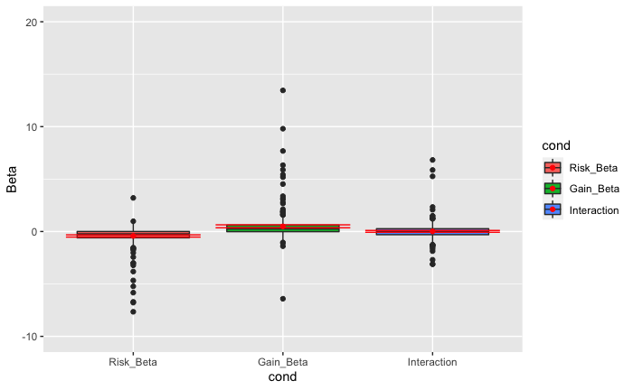

```r
coefficients = lapply(subjectModel.2, coef)
coefficients = do.call(rbind, coefficients)
coefficients = coefficients[,-1]#Removes intercept
#coefficients = coefficients[,3]#Removes interaction
coefficients = data.frame(coefficients)
colnames(coefficients)= c('Risk_Beta', 'Gain_Beta', 'Interaction')
coefficients$user_id = names(subjectModel.2)
#coefficients = exp(coefficients)#exponetiated
# A basic box with the conditions colored
dat <- melt(coefficients,
                       id = c("user_id"),
                       variable.name = "cond",
                       value.name = "Beta")
ggplot(dat, aes(x=cond, y=Beta, fill=cond)) + geom_boxplot()+
  stat_summary(fun.data = mean_cl_boot, geom = "errorbar", colour = "red") +
    stat_summary(fun.y = mean, geom = "point", colour = "red")+
      scale_y_continuous(limits=c(-10, 20))
```

[figure not shown]

[output not shown]

```r
dat.2 = distinct(select(Neuroethics_Judgement, user_id , condition, sex, age, education, Risk_sig, Gain_sig, Interaction_sig))

dat.2$user_id <- as.factor(dat.2$user_id)
dat.2$education <- as.factor(dat.2$education)

data_long.2 = melt(dat.2,
            id = c("user_id", "condition", "sex", "education", "age"),
                       variable.name = "type",
                       value.name = "Stimulus")

#Significant plots
ggplot(data_long.2, aes(x = type, fill = as.factor(Stimulus))) +
         geom_bar(color = 'black', stat="count", position = "dodge")+
         theme_classic()
```

## H2

Participants risk aversion to harm will change as the cognitive domain being treated changes. Specifically, participants will be more risk averse to mood, and self-control because these are more central to self-identity.

```r
#LOAD THE DATA SET FROM THE CLEANED ONE

dat.1 = distinct(select(Neuroethics_Judgement, user_id , condition ,  Risk_Beta , Gain_Beta , Interaction_Beta, sex, age, education, trial_index))


dat.1 = melt(dat.1,
            id = c("user_id", "condition", "sex", "education", "age", "trial_index"),
                       variable.name = "type",
                       value.name = "Stimulus")


#dat.1$type <- relevel(dat.1$type, "")
library(lme4)
library(lmerTest)
#scale the continuous variables
dat.1$Stimulus_c <- scale(dat.1$Stimulus)
dat.1$age_c <- scale(dat.1$age)
dat.1$trial_index <- as.numeric(dat.1$trial_index)
dat.1$trial_index_c <- scale(dat.1$trial_index)


m.base <- lmer(Stimulus ~ trial_index_c +
                      (1 | condition),
                      data = dat.1,REML=F)

m.0 <- lmer(Stimulus ~ trial_index_c + condition +
                      (1 | condition),
                      data = dat.1,REML=F)

m.1 <- lmer(Stimulus ~ trial_index_c + condition + age_c +
                      (1 | condition),
                      data = dat.1,REML=F)

m.2 <- lmer(Stimulus ~ trial_index_c + condition + age_c + sex +
                      (1 | condition),
                      data = dat.1,REML=F)

m.3 <- lmer(Stimulus ~ trial_index_c + condition + age_c + sex + education +
                      (1 | condition),
                      data = dat.1,REML=F)

m.4 <- lmer(Stimulus ~ trial_index_c*condition + age_c + sex + education +
                      (1 | condition),
                      data = dat.1,REML=F)


anova(m.base, m.0, m.1, m.2, m.3, m.4)


plot(m.3, condition ~ resid(.), abline = 0 ) # generate diagnostic plots

plot(m.3, resid(., type = "pearson") ~ fitted(.) | condition, id = 0.05,
     adj = -0.3, pch = 20, col = "gray40")

library(car)
# check homogeneity
#Computes Levene's test for homogeneity of variance across groups.


leveneTest(dat.1$Stimulus, dat.1$condition, center = mean)

plot(m.3, pch = 20, col = "black", lty = "dotted")

plot(m.3, form = resid(., type = "pearson") ~ fitted(.) | condition, abline = 0,
     cex = .5, pch = 20, col = "black")

# observed responses versus the within-group fitted values
plot(m.3, Stimulus ~ fitted(.), id = 0.05, adj = -0.3, cex = .8, pch = 20, col = "blue")
```

## Testing stuff

```r
library(reshape2)
library(lme4)
library(lmerTest)
feee <- Neuroethics_Judgement

center_scale <- function(x) {
    scale(x, scale = FALSE)
}
multilevel.data <- dplyr::select(feee, user_id, condition, risk, gain, experimental_treatment_selected, trial_index, age_4, sex)

multilevel.data$user_id <- as.factor(multilevel.data$user_id)
multilevel.data$trial_index.c <- center_scale(as.numeric(multilevel.data$trial_index))
multilevel.data$age.c <- center_scale(multilevel.data$age_4)
multilevel.data$risk.c <- center_scale(multilevel.data$risk)
multilevel.data$gain.c <- center_scale(multilevel.data$gain)


m.base <- glmer(experimental_treatment_selected ~ 1 + (1 + trial_index | condition),
               data = multilevel.data, family = binomial,
               control=glmerControl(optimizer="bobyqa"))

m.1 <- glmer(experimental_treatment_selected ~ 1 + trial_index*risk.c*gain.c + age.c + (1 + trial_index| condition), data = multilevel.data, family = binomial,
               control=glmerControl(optimizer="bobyqa"), nAGQ = 10)


ggplot(multilevel.data, aes(risk, experimental_treatment_selected, color = condition, shape = user_id))+


  stat_summary(fun.data=mean_se, geom="pointrange") +
   stat_summary(fun=mean, geom="line", linetype = 2) +
   labs(x="risk", y="Chosen experimental treatment") +
   theme_bw()+theme(legend.position="none")




library(gridExtra)

grid.arrange(p1,p2,ncol=2)
```

```r
for (i in user_id){
  subject = filter(datalist.dignostics, user_id == i)

 p1 <-  ggplot(subject, aes(x=risk, y= standardized.residuals)) +
          geom_point(position = 'jitter')+
          stat_smooth(method="glm", se=FALSE, fullrange=TRUE,
              method.args = list(family=quasibinomial))+
          scale_x_continuous(expand = c(0,0))+
          scale_y_continuous("Mean Responce (0 = No 1 = Yes)",breaks=seq(0,1,0.25),
                            limits=c(0, 1))

  p2 <- ggplot(subject, aes(x=gain, y= predicted.probabilities)) +
           stat_summary(fun = mean, geom = "line")+

           scale_x_continuous(expand = c(0,0))+
          scale_y_continuous("Mean Responce (0 = No 1 = Yes)",breaks=seq(0,1,0.25),
                            limits=c(0, 1))
   png(filename = paste0(i , ".png"),
       width = 1234, height = 468)
     multiplot(p1, p2, cols=2)
     dev.off()
}
```